# Bank Churn Prediction - Problem Statement

### **Model 6**

Applying results of the Keras Tuner, Smote, and Random Search

```python
backend.clear_session()
np.random.seed(1)
import random
random.seed(1)
tf.random.set_seed(1)
```

```python
model6 = Sequential()
model6.add(Dense(160,activation='relu',kernel_initializer='he_uniform',input_dim = X_train.shape[1]))
model6.add(Dense(160,activation='relu',kernel_initializer='he_uniform'))
model6.add(Dense(224,activation='relu',kernel_initializer='he_uniform'))
model6.add(Dense(96,activation='relu',kernel_initializer='he_uniform'))
model6.add(Dense(160,activation='relu',kernel_initializer='he_uniform'))
model6.add(Dense(64,activation='relu',kernel_initializer='he_uniform'))
model6.add(Dense(64,activation='relu',kernel_initializer='he_uniform'))
model6.add(Dense(192,activation='relu',kernel_initializer='he_uniform'))
model6.add(Dense(1, activation = 'sigmoid'))
```

```python
model6.summary()
```

```
Model: "sequential"
_________________________________________________________________
 Layer (type)                Output Shape              Param #
=================================================================
 dense (Dense)               (None, 160)               1600

 dense_1 (Dense)             (None, 160)               25760

 dense_2 (Dense)             (None, 224)               36064

 dense_3 (Dense)             (None, 96)                21600

 dense_4 (Dense)             (None, 160)               15520

 dense_5 (Dense)             (None, 64)                10304

 dense_6 (Dense)             (None, 64)                4160

 dense_7 (Dense)             (None, 192)               12480

 dense_8 (Dense)             (None, 1)                 193

=================================================================
Total params: 127,681
Trainable params: 127,681
Non-trainable params: 0
_________________________________________________________________
```

```python
optimizer = tf.keras.optimizers.Adam(0.001)
model6.compile(loss='binary_crossentropy',optimizer=optimizer,metrics=['accuracy'])
```

```python
history_6 = model6.fit(X_sm,y_sm,batch_size=32,epochs=50,verbose=1,validation_split = 0.2)
```

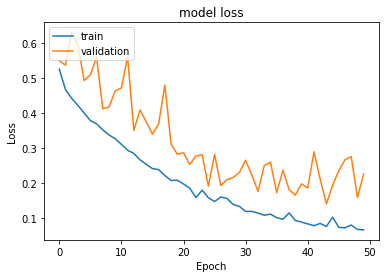

```python
#Plotting Train Loss vs Validation Loss
plt.plot(history_6.history['loss'])
plt.plot(history_6.history['val_loss'])
plt.title('model loss')
plt.ylabel('Loss')
plt.xlabel('Epoch')
plt.legend(['train', 'validation'], loc='upper left')
plt.show()
```

#### Observations

- This is relatively smoother than some of the other models but not quite as smooth as Model 4.

```
Best Threshold=0.049712, G-Mean=0.715
```

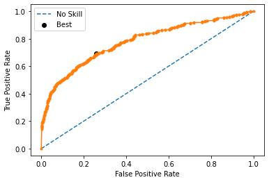

```python
from sklearn.metrics import roc_curve
from matplotlib import pyplot

# predict probabilities
yhat6 = model6.predict(X_test)
# keep probabilities for the positive outcome only
yhat6 = yhat6[:, 0]
# calculate roc curves
fpr, tpr, thresholds6 = roc_curve(y_test, yhat6)
# calculate the g-mean for each threshold
gmeans6 = np.sqrt(tpr * (1-fpr))
# locate the index of the largest g-mean
ix = np.argmax(gmeans6)
print('Best Threshold=%f, G-Mean=%.3f' % (thresholds6[ix], gmeans6[ix]))
# plot the roc curve for the model
pyplot.plot([0,1], [0,1], linestyle='--', label='No Skill')
pyplot.plot(fpr, tpr, marker='.')
pyplot.scatter(fpr[ix], tpr[ix], marker='o', color='black', label='Best')
# axis labels
pyplot.xlabel('False Positive Rate')
pyplot.ylabel('True Positive Rate')
pyplot.legend()
# show the plot
pyplot.show()
```

```python
y_pred_e6=model6.predict(X_test)
y_pred_e6 = (y_pred_e6 > thresholds6[ix])
```

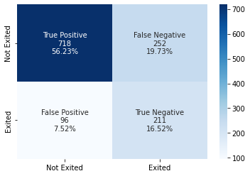

```python
#Calculating the confusion matrix
from sklearn.metrics import confusion_matrix
cm6=confusion_matrix(y_test, y_pred_e6)
labels = ['True Positive','False Negative','False Positive','True Negative']
categories = [ 'Not Exited','Exited']
make_confusion_matrix(cm6,
                      group_names=labels,
                      categories=categories,
                      cmap='Blues')
```

```python
#Accuracy as per the classification report
from sklearn import metrics
cr6=metrics.classification_report(y_test,y_pred_e6)
print(cr6)
```

```
              precision    recall  f1-score   support

           0       0.88      0.74      0.80       970
           1       0.46      0.69      0.55       307

    accuracy                           0.73      1277
   macro avg       0.67      0.71      0.68      1277
weighted avg       0.78      0.73      0.74      1277
```

#### Observations

- The performance is reasonably good.
- The model is relatively smoother than most of the other models.
- The Recall on Exited = 1 is .69 and F1 Score is .55.
- However, the best scores we got are still on Model 2 with just SMOTE and Model 4 with BatchNormalization.

## Conclusion

- The best performing Model appears to be Model 2. It employs Smote with a single hidden layer. It returns a recall score of 78 and an F1 Score of 75.
- The Estimated Salary doesnt seem to be generating valid results and can be ignored. I would not expect all levels of salary to be approximately equal across the entire population.
- It seems like members who have more than 2 products are likely to attrit. It is encouraged that the bank look into why members who acquire more products which should build loyalty are instead leaving the bank. Is there a product or service that is turning those customers off?
- As one might expect, members who are inactive are likely to attrit. The bank should consider reaching out to members who are flagged as inactive and possibly offer them incentive to become active again.
- It would be worthwhile to survey both new members and members who have been with the bank for 9-10 years as they are most likely to attrit.